# W3cubDocs

/GTK 3.24

# GtkPlacesSidebar

GtkPlacesSidebar — Sidebar that displays frequently-used places in the file system

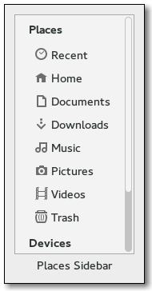

## Functions

| GtkWidget * | gtk_places_sidebar_new () |
| --- | --- |
| void | gtk_places_sidebar_set_open_flags () |
| GtkPlacesOpenFlags | gtk_places_sidebar_get_open_flags () |
| void | gtk_places_sidebar_set_location () |
| GFile * | gtk_places_sidebar_get_location () |
| void | gtk_places_sidebar_set_show_recent () |
| gboolean | gtk_places_sidebar_get_show_recent () |
| void | gtk_places_sidebar_set_show_desktop () |
| gboolean | gtk_places_sidebar_get_show_desktop () |
| void | gtk_places_sidebar_add_shortcut () |
| void | gtk_places_sidebar_remove_shortcut () |
| GSList * | gtk_places_sidebar_list_shortcuts () |
| GFile * | gtk_places_sidebar_get_nth_bookmark () |
| gboolean | gtk_places_sidebar_get_show_connect_to_server () |
| void | gtk_places_sidebar_set_show_connect_to_server () |
| gboolean | gtk_places_sidebar_get_local_only () |
| void | gtk_places_sidebar_set_local_only () |
| gboolean | gtk_places_sidebar_get_show_enter_location () |
| void | gtk_places_sidebar_set_show_enter_location () |
| gboolean | gtk_places_sidebar_get_show_trash () |
| void | gtk_places_sidebar_set_show_trash () |
| gboolean | gtk_places_sidebar_get_show_other_locations () |
| void | gtk_places_sidebar_set_show_other_locations () |
| void | gtk_places_sidebar_set_drop_targets_visible () |

## Properties

| gboolean | local-only | Read / Write |
| --- | --- | --- |
| GFile * | location | Read / Write |
| GtkPlacesOpenFlags | open-flags | Read / Write |
| gboolean | populate-all | Read / Write |
| gboolean | show-connect-to-server | Read / Write |
| gboolean | show-desktop | Read / Write |
| gboolean | show-enter-location | Read / Write |
| gboolean | show-other-locations | Read / Write |
| gboolean | show-recent | Read / Write |
| gboolean | show-starred-location | Read / Write |
| gboolean | show-trash | Read / Write |

## Signals

| int | drag-action-ask | Run Last |
| --- | --- | --- |
| int | drag-action-requested | Run Last |
| void | drag-perform-drop | Run First |
| void | mount | Run First |
| void | open-location | Run First |
| void | populate-popup | Run First |
| void | show-connect-to-server | Run First |
| void | show-enter-location | Run First |
| void | show-error-message | Run First |
| void | show-other-locations | Run First |
| void | show-other-locations-with-flags | Run First |
| void | show-starred-location | Run First |
| void | unmount | Run First |

## Types and Values

|  | GtkPlacesSidebar |
| --- | --- |
| enum | GtkPlacesOpenFlags |

## Object Hierarchy

```
    GObject
    ╰── GInitiallyUnowned
        ╰── GtkWidget
            ╰── GtkContainer
                ╰── GtkBin
                    ╰── GtkScrolledWindow
                        ╰── GtkPlacesSidebar
```

## Implemented Interfaces

GtkPlacesSidebar implements AtkImplementorIface and GtkBuildable.

## Includes

```
#include <gtk/gtk.h>
```

## Description

GtkPlacesSidebar is a widget that displays a list of frequently-used places in the file system: the user’s home directory, the user’s bookmarks, and volumes and drives. This widget is used as a sidebar in GtkFileChooser and may be used by file managers and similar programs.

The places sidebar displays drives and volumes, and will automatically mount or unmount them when the user selects them.

Applications can hook to various signals in the places sidebar to customize its behavior. For example, they can add extra commands to the context menu of the sidebar.

While bookmarks are completely in control of the user, the places sidebar also allows individual applications to provide extra shortcut folders that are unique to each application. For example, a Paint program may want to add a shortcut for a Clipart folder. You can do this with `gtk_places_sidebar_add_shortcut()`.

To make use of the places sidebar, an application at least needs to connect to the “open-location” signal. This is emitted when the user selects in the sidebar a location to open. The application should also call `gtk_places_sidebar_set_location()` when it changes the currently-viewed location.

### CSS nodes

GtkPlacesSidebar uses a single CSS node with name placessidebar and style class .sidebar.

Among the children of the places sidebar, the following style classes can be used:

- .sidebar-new-bookmark-row for the 'Add new bookmark' row
- .sidebar-placeholder-row for a row that is a placeholder
- .has-open-popup when a popup is open for a row

## Functions

### gtk_places_sidebar_new ()

```
GtkWidget *
gtk_places_sidebar_new (void);
```

Creates a new GtkPlacesSidebar widget.

The application should connect to at least the “open-location” signal to be notified when the user makes a selection in the sidebar.

#### Returns

a newly created GtkPlacesSidebar

Since: 3.10

### gtk_places_sidebar_set_open_flags ()

```
void
gtk_places_sidebar_set_open_flags (GtkPlacesSidebar *sidebar,
                                   GtkPlacesOpenFlags flags);
```

Sets the way in which the calling application can open new locations from the places sidebar. For example, some applications only open locations “directly” into their main view, while others may support opening locations in a new notebook tab or a new window.

This function is used to tell the places *`sidebar`* about the ways in which the application can open new locations, so that the sidebar can display (or not) the “Open in new tab” and “Open in new window” menu items as appropriate.

When the “open-location” signal is emitted, its flags argument will be set to one of the *`flags`* that was passed in `gtk_places_sidebar_set_open_flags()`.

Passing 0 for *`flags`* will cause GTK_PLACES_OPEN_NORMAL to always be sent to callbacks for the “open-location” signal.

#### Parameters

| sidebar | a places sidebar |  |
| --- | --- | --- |
| flags | Bitmask of modes in which the calling application can open locations |  |

Since: 3.10

### gtk_places_sidebar_get_open_flags ()

```
GtkPlacesOpenFlags
gtk_places_sidebar_get_open_flags (GtkPlacesSidebar *sidebar);
```

Gets the open flags.

#### Parameters

| sidebar | a GtkPlacesSidebar |  |
| --- | --- | --- |

#### Returns

the GtkPlacesOpenFlags of *`sidebar`*

Since: 3.10

### gtk_places_sidebar_set_location ()

```
void
gtk_places_sidebar_set_location (GtkPlacesSidebar *sidebar,
                                 GFile *location);
```

Sets the location that is being shown in the widgets surrounding the *`sidebar`* , for example, in a folder view in a file manager. In turn, the *`sidebar`* will highlight that location if it is being shown in the list of places, or it will unhighlight everything if the *`location`* is not among the places in the list.

#### Parameters

| sidebar | a places sidebar |  |
| --- | --- | --- |
| location | location to select, or `NULL` for no current path. | [nullable] |

Since: 3.10

### gtk_places_sidebar_get_location ()

```
GFile *
gtk_places_sidebar_get_location (GtkPlacesSidebar *sidebar);
```

Gets the currently selected location in the *`sidebar`* . This can be `NULL` when nothing is selected, for example, when `gtk_places_sidebar_set_location()` has been called with a location that is not among the sidebar’s list of places to show.

You can use this function to get the selection in the *`sidebar`* . Also, if you connect to the “populate-popup” signal, you can use this function to get the location that is being referred to during the callbacks for your menu items.

#### Parameters

| sidebar | a places sidebar |  |
| --- | --- | --- |

#### Returns

a GFile with the selected location, or `NULL` if nothing is visually selected.

[nullable][transfer full]

Since: 3.10

### gtk_places_sidebar_set_show_recent ()

```
void
gtk_places_sidebar_set_show_recent (GtkPlacesSidebar *sidebar,
                                    gboolean show_recent);
```

Sets whether the *`sidebar`* should show an item for recent files. The default value for this option is determined by the desktop environment, but this function can be used to override it on a per-application basis.

#### Parameters

| sidebar | a places sidebar |  |
| --- | --- | --- |
| show_recent | whether to show an item for recent files |  |

Since: 3.18

### gtk_places_sidebar_get_show_recent ()

```
gboolean
gtk_places_sidebar_get_show_recent (GtkPlacesSidebar *sidebar);
```

Returns the value previously set with `gtk_places_sidebar_set_show_recent()`

#### Parameters

| sidebar | a places sidebar |  |
| --- | --- | --- |

#### Returns

`TRUE` if the sidebar will display a builtin shortcut for recent files

Since: 3.18

### gtk_places_sidebar_set_show_desktop ()

```
void
gtk_places_sidebar_set_show_desktop (GtkPlacesSidebar *sidebar,
                                     gboolean show_desktop);
```

Sets whether the *`sidebar`* should show an item for the Desktop folder. The default value for this option is determined by the desktop environment and the user’s configuration, but this function can be used to override it on a per-application basis.

#### Parameters

| sidebar | a places sidebar |  |
| --- | --- | --- |
| show_desktop | whether to show an item for the Desktop folder |  |

Since: 3.10

### gtk_places_sidebar_get_show_desktop ()

```
gboolean
gtk_places_sidebar_get_show_desktop (GtkPlacesSidebar *sidebar);
```

Returns the value previously set with `gtk_places_sidebar_set_show_desktop()`

#### Parameters

| sidebar | a places sidebar |  |
| --- | --- | --- |

#### Returns

`TRUE` if the sidebar will display a builtin shortcut to the desktop folder.

Since: 3.10

### gtk_places_sidebar_add_shortcut ()

```
void
gtk_places_sidebar_add_shortcut (GtkPlacesSidebar *sidebar,
                                 GFile *location);
```

Applications may want to present some folders in the places sidebar if they could be immediately useful to users. For example, a drawing program could add a “/usr/share/clipart” location when the sidebar is being used in an “Insert Clipart” dialog box.

This function adds the specified *`location`* to a special place for immutable shortcuts. The shortcuts are application-specific; they are not shared across applications, and they are not persistent. If this function is called multiple times with different locations, then they are added to the sidebar’s list in the same order as the function is called.

#### Parameters

| sidebar | a places sidebar |  |
| --- | --- | --- |
| location | location to add as an application-specific shortcut |  |

Since: 3.10

### gtk_places_sidebar_remove_shortcut ()

```
void
gtk_places_sidebar_remove_shortcut (GtkPlacesSidebar *sidebar,
                                    GFile *location);
```

Removes an application-specific shortcut that has been previously been inserted with `gtk_places_sidebar_add_shortcut()`. If the *`location`* is not a shortcut in the sidebar, then nothing is done.

#### Parameters

| sidebar | a places sidebar |  |
| --- | --- | --- |
| location | location to remove |  |

Since: 3.10

### gtk_places_sidebar_list_shortcuts ()

```
GSList *
gtk_places_sidebar_list_shortcuts (GtkPlacesSidebar *sidebar);
```

Gets the list of shortcuts.

#### Parameters

| sidebar | a places sidebar |  |
| --- | --- | --- |

#### Returns

A GSList of GFile of the locations that have been added as application-specific shortcuts with `gtk_places_sidebar_add_shortcut()`. To free this list, you can use

```
g_slist_free_full (list, (GDestroyNotify) g_object_unref);
```

.

[element-type GFile][transfer full]

Since: 3.10

### gtk_places_sidebar_get_nth_bookmark ()

```
GFile *
gtk_places_sidebar_get_nth_bookmark (GtkPlacesSidebar *sidebar,
                                     gint n);
```

This function queries the bookmarks added by the user to the places sidebar, and returns one of them. This function is used by GtkFileChooser to implement the “Alt-1”, “Alt-2”, etc. shortcuts, which activate the cooresponding bookmark.

#### Parameters

| sidebar | a places sidebar |  |
| --- | --- | --- |
| n | index of the bookmark to query |  |

#### Returns

The bookmark specified by the index *`n`* , or `NULL` if no such index exist. Note that the indices start at 0, even though the file chooser starts them with the keyboard shortcut "Alt-1".

[nullable][transfer full]

Since: 3.10

### gtk_places_sidebar_get_show_connect_to_server ()

```
gboolean
gtk_places_sidebar_get_show_connect_to_server
                               (GtkPlacesSidebar *sidebar);
```

`gtk_places_sidebar_get_show_connect_to_server` has been deprecated since version 3.18 and should not be used in newly-written code.

It is recommended to group this functionality with the drives and network location under the new 'Other Location' item

Returns the value previously set with `gtk_places_sidebar_set_show_connect_to_server()`

#### Parameters

| sidebar | a places sidebar |  |
| --- | --- | --- |

#### Returns

`TRUE` if the sidebar will display a “Connect to Server” item.

### gtk_places_sidebar_set_show_connect_to_server ()

```
void
gtk_places_sidebar_set_show_connect_to_server
                               (GtkPlacesSidebar *sidebar,
                                gboolean show_connect_to_server);
```

`gtk_places_sidebar_set_show_connect_to_server` has been deprecated since version 3.18 and should not be used in newly-written code.

It is recommended to group this functionality with the drives and network location under the new 'Other Location' item

Sets whether the *`sidebar`* should show an item for connecting to a network server; this is off by default. An application may want to turn this on if it implements a way for the user to connect to network servers directly.

If you enable this, you should connect to the “show-connect-to-server” signal.

#### Parameters

| sidebar | a places sidebar |  |
| --- | --- | --- |
| show_connect_to_server | whether to show an item for the Connect to Server command |  |

Since: 3.10

### gtk_places_sidebar_get_local_only ()

```
gboolean
gtk_places_sidebar_get_local_only (GtkPlacesSidebar *sidebar);
```

Returns the value previously set with `gtk_places_sidebar_set_local_only()`.

#### Parameters

| sidebar | a places sidebar |  |
| --- | --- | --- |

#### Returns

`TRUE` if the sidebar will only show local files.

Since: 3.12

### gtk_places_sidebar_set_local_only ()

```
void
gtk_places_sidebar_set_local_only (GtkPlacesSidebar *sidebar,
                                   gboolean local_only);
```

Sets whether the *`sidebar`* should only show local files.

#### Parameters

| sidebar | a places sidebar |  |
| --- | --- | --- |
| local_only | whether to show only local files |  |

Since: 3.12

### gtk_places_sidebar_get_show_enter_location ()

```
gboolean
gtk_places_sidebar_get_show_enter_location
                               (GtkPlacesSidebar *sidebar);
```

Returns the value previously set with `gtk_places_sidebar_set_show_enter_location()`

#### Parameters

| sidebar | a places sidebar |  |
| --- | --- | --- |

#### Returns

`TRUE` if the sidebar will display an “Enter Location” item.

Since: 3.14

### gtk_places_sidebar_set_show_enter_location ()

```
void
gtk_places_sidebar_set_show_enter_location
                               (GtkPlacesSidebar *sidebar,
                                gboolean show_enter_location);
```

Sets whether the *`sidebar`* should show an item for entering a location; this is off by default. An application may want to turn this on if manually entering URLs is an expected user action.

If you enable this, you should connect to the “show-enter-location” signal.

#### Parameters

| sidebar | a places sidebar |  |
| --- | --- | --- |
| show_enter_location | whether to show an item to enter a location |  |

Since: 3.14

### gtk_places_sidebar_get_show_trash ()

```
gboolean
gtk_places_sidebar_get_show_trash (GtkPlacesSidebar *sidebar);
```

Returns the value previously set with `gtk_places_sidebar_set_show_trash()`

#### Parameters

| sidebar | a places sidebar |  |
| --- | --- | --- |

#### Returns

`TRUE` if the sidebar will display a “Trash” item.

Since: 3.18

### gtk_places_sidebar_set_show_trash ()

```
void
gtk_places_sidebar_set_show_trash (GtkPlacesSidebar *sidebar,
                                   gboolean show_trash);
```

Sets whether the *`sidebar`* should show an item for the Trash location.

#### Parameters

| sidebar | a places sidebar |  |
| --- | --- | --- |
| show_trash | whether to show an item for the Trash location |  |

Since: 3.18

### gtk_places_sidebar_get_show_other_locations ()

```
gboolean
gtk_places_sidebar_get_show_other_locations
                               (GtkPlacesSidebar *sidebar);
```

Returns the value previously set with `gtk_places_sidebar_set_show_other_locations()`

#### Parameters

| sidebar | a places sidebar |  |
| --- | --- | --- |

#### Returns

`TRUE` if the sidebar will display an “Other Locations” item.

Since: 3.18

### gtk_places_sidebar_set_show_other_locations ()

```
void
gtk_places_sidebar_set_show_other_locations
                               (GtkPlacesSidebar *sidebar,
                                gboolean show_other_locations);
```

Sets whether the *`sidebar`* should show an item for the application to show an Other Locations view; this is off by default. When set to `TRUE`, persistent devices such as hard drives are hidden, otherwise they are shown in the sidebar. An application may want to turn this on if it implements a way for the user to see and interact with drives and network servers directly.

If you enable this, you should connect to the “show-other-locations” signal.

#### Parameters

| sidebar | a places sidebar |  |
| --- | --- | --- |
| show_other_locations | whether to show an item for the Other Locations view |  |

Since: 3.18

### gtk_places_sidebar_set_drop_targets_visible ()

```
void
gtk_places_sidebar_set_drop_targets_visible
                               (GtkPlacesSidebar *sidebar,
                                gboolean visible,
                                GdkDragContext *context);
```

Make the GtkPlacesSidebar show drop targets, so it can show the available drop targets and a "new bookmark" row. This improves the Drag-and-Drop experience of the user and allows applications to show all available drop targets at once.

This needs to be called when the application is aware of an ongoing drag that might target the sidebar. The drop-targets-visible state will be unset automatically if the drag finishes in the GtkPlacesSidebar. You only need to unset the state when the drag ends on some other widget on your application.

#### Parameters

| sidebar | a places sidebar. |  |
| --- | --- | --- |
| visible | whether to show the valid targets or not. |  |
| context | drag context used to ask the source about the action that wants to perform, so hints are more accurate. |  |

Since: 3.18

## Types and Values

### GtkPlacesSidebar

```
typedef struct _GtkPlacesSidebar GtkPlacesSidebar;
```

### enum GtkPlacesOpenFlags

These flags serve two purposes. First, the application can call `gtk_places_sidebar_set_open_flags()` using these flags as a bitmask. This tells the sidebar that the application is able to open folders selected from the sidebar in various ways, for example, in new tabs or in new windows in addition to the normal mode.

Second, when one of these values gets passed back to the application in the “open-location” signal, it means that the application should open the selected location in the normal way, in a new tab, or in a new window. The sidebar takes care of determining the desired way to open the location, based on the modifier keys that the user is pressing at the time the selection is made.

If the application never calls `gtk_places_sidebar_set_open_flags()`, then the sidebar will only use GTK_PLACES_OPEN_NORMAL in the “open-location” signal. This is the default mode of operation.

#### Members

[output not shown]

## Property Details

### The `“local-only”` property

```
  “local-only”               gboolean
```

Whether the sidebar only includes local files.

Owner: GtkPlacesSidebar

Flags: Read / Write

Default value: FALSE

### The `“location”` property

```
  “location”                 GFile *
```

The location to highlight in the sidebar.

Owner: GtkPlacesSidebar

Flags: Read / Write

### The `“open-flags”` property

```
  “open-flags”               GtkPlacesOpenFlags
```

Modes in which the calling application can open locations selected in the sidebar.

Owner: GtkPlacesSidebar

Flags: Read / Write

Default value: GTK_PLACES_OPEN_NORMAL

### The `“populate-all”` property

```
  “populate-all”             gboolean
```

If :populate-all is `TRUE`, the “populate-popup” signal is also emitted for popovers.

Owner: GtkPlacesSidebar

Flags: Read / Write

Default value: FALSE

Since: 3.18

### The `“show-connect-to-server”` property

```
  “show-connect-to-server”   gboolean
```

Whether the sidebar includes a builtin shortcut to a 'Connect to server' dialog.

Owner: GtkPlacesSidebar

Flags: Read / Write

Default value: FALSE

### The `“show-desktop”` property

```
  “show-desktop”             gboolean
```

Whether the sidebar includes a builtin shortcut to the Desktop folder.

Owner: GtkPlacesSidebar

Flags: Read / Write

Default value: TRUE

### The `“show-enter-location”` property

```
  “show-enter-location”      gboolean
```

Whether the sidebar includes a builtin shortcut to manually enter a location.

Owner: GtkPlacesSidebar

Flags: Read / Write

Default value: FALSE

### The `“show-other-locations”` property

```
  “show-other-locations”     gboolean
```

Whether the sidebar includes an item to show external locations.

Owner: GtkPlacesSidebar

Flags: Read / Write

Default value: FALSE

### The `“show-recent”` property

```
  “show-recent”              gboolean
```

Whether the sidebar includes a builtin shortcut for recent files.

Owner: GtkPlacesSidebar

Flags: Read / Write

Default value: TRUE

### The `“show-starred-location”` property

```
  “show-starred-location”    gboolean
```

Whether the sidebar includes an item to show starred files.

Owner: GtkPlacesSidebar

Flags: Read / Write

Default value: FALSE

### The `“show-trash”` property

```
  “show-trash”               gboolean
```

Whether the sidebar includes a builtin shortcut to the Trash location.

Owner: GtkPlacesSidebar

Flags: Read / Write

Default value: TRUE

## Signal Details

### The `“drag-action-ask”` signal

```
int
user_function (GtkPlacesSidebar *sidebar,
               int               actions,
               gpointer          user_data)
```

The places sidebar emits this signal when it needs to ask the application to pop up a menu to ask the user for which drag action to perform.

#### Parameters

| sidebar | the object which received the signal. |  |
| --- | --- | --- |
| actions | Possible drag actions that need to be asked for. |  |
| user_data | user data set when the signal handler was connected. |  |

#### Returns

the final drag action that the sidebar should pass to the drag side of the drag-and-drop operation.

Flags: Run Last

Since: 3.10

### The `“drag-action-requested”` signal

```
int
user_function (GtkPlacesSidebar *sidebar,
               GdkDragContext   *context,
               GObject          *dest_file,
               gpointer          source_file_list,
               gpointer          user_data)
```

When the user starts a drag-and-drop operation and the sidebar needs to ask the application for which drag action to perform, then the sidebar will emit this signal.

The application can evaluate the *`context`* for customary actions, or it can check the type of the files indicated by *`source_file_list`* against the possible actions for the destination *`dest_file`* .

The drag action to use must be the return value of the signal handler.

#### Parameters

| sidebar | the object which received the signal. |  |
| --- | --- | --- |
| context | [GdkDragContext](https://developer.gnome.org/gtk3/html/gdk3-Drag-and-Drop.html#GdkDragContext-struct) with information about the drag operation. | [type Gdk.DragContext] |
| dest_file | GFile with the tentative location that is being hovered for a drop. | [type Gio.File] |
| source_file_list | List of GFile that are being dragged. | [type GLib.List][element-type GFile][transfer none] |
| user_data | user data set when the signal handler was connected. |  |

#### Returns

The drag action to use, for example, [GDK_ACTION_COPY](https://developer.gnome.org/gtk3/html/gdk3-Drag-and-Drop.html#GDK-ACTION-COPY:CAPS) or [GDK_ACTION_MOVE](https://developer.gnome.org/gtk3/html/gdk3-Drag-and-Drop.html#GDK-ACTION-MOVE:CAPS), or 0 if no action is allowed here (i.e. drops are not allowed in the specified *`dest_file`* ).

Flags: Run Last

Since: 3.10

### The `“drag-perform-drop”` signal

```
void
user_function (GtkPlacesSidebar *sidebar,
               GObject          *dest_file,
               gpointer          source_file_list,
               int               action,
               gpointer          user_data)
```

The places sidebar emits this signal when the user completes a drag-and-drop operation and one of the sidebar's items is the destination. This item is in the *`dest_file`* , and the *`source_file_list`* has the list of files that are dropped into it and which should be copied/moved/etc. based on the specified *`action`* .

#### Parameters

| sidebar | the object which received the signal. |  |
| --- | --- | --- |
| dest_file | Destination GFile. | [type Gio.File] |
| source_file_list | GList of GFile that got dropped. | [type GLib.List][element-type GFile][transfer none] |
| action | Drop action to perform. |  |
| user_data | user data set when the signal handler was connected. |  |

Flags: Run First

Since: 3.10

### The `“mount”` signal

```
void
user_function (GtkPlacesSidebar *sidebar,
               GMountOperation  *mount_operation,
               gpointer          user_data)
```

The places sidebar emits this signal when it starts a new operation because the user clicked on some location that needs mounting. In this way the application using the GtkPlacesSidebar can track the progress of the operation and, for example, show a notification.

#### Parameters

| sidebar | the object which received the signal. |  |
| --- | --- | --- |
| mount_operation | the GMountOperation that is going to start. |  |
| user_data | user data set when the signal handler was connected. |  |

Flags: Run First

Since: 3.20

### The `“open-location”` signal

```
void
user_function (GtkPlacesSidebar  *sidebar,
               GObject           *location,
               GtkPlacesOpenFlags open_flags,
               gpointer           user_data)
```

The places sidebar emits this signal when the user selects a location in it. The calling application should display the contents of that location; for example, a file manager should show a list of files in the specified location.

#### Parameters

| sidebar | the object which received the signal. |  |
| --- | --- | --- |
| location | GFile to which the caller should switch. | [type Gio.File] |
| open_flags | a single value from GtkPlacesOpenFlags specifying how the *`location`* should be opened. |  |
| user_data | user data set when the signal handler was connected. |  |

Flags: Run First

Since: 3.10

### The `“populate-popup”` signal

```
void
user_function (GtkPlacesSidebar *sidebar,
               GtkWidget        *container,
               GFile            *selected_item,
               GVolume          *selected_volume,
               gpointer          user_data)
```

The places sidebar emits this signal when the user invokes a contextual popup on one of its items. In the signal handler, the application may add extra items to the menu as appropriate. For example, a file manager may want to add a "Properties" command to the menu.

It is not necessary to store the *`selected_item`* for each menu item; during their callbacks, the application can use `gtk_places_sidebar_get_location()` to get the file to which the item refers.

The *`selected_item`* argument may be `NULL` in case the selection refers to a volume. In this case, *`selected_volume`* will be non-`NULL`. In this case, the calling application will have to `g_object_ref()` the *`selected_volume`* and keep it around to use it in the callback.

The *`container`* and all its contents are destroyed after the user dismisses the popup. The popup is re-created (and thus, this signal is emitted) every time the user activates the contextual menu.

Before 3.18, the *`container`* always was a GtkMenu, and you were expected to add your items as GtkMenuItems. Since 3.18, the popup may be implemented as a GtkPopover, in which case *`container`* will be something else, e.g. a GtkBox, to which you may add GtkModelButtons or other widgets, such as GtkEntries, GtkSpinButtons, etc. If your application can deal with this situation, you can set “populate-all” to `TRUE` to request that this signal is emitted for populating popovers as well.

#### Parameters

| sidebar | the object which received the signal. |  |
| --- | --- | --- |
| container | a GtkMenu or another GtkContainer. | [type Gtk.Widget] |
| selected_item | GFile with the item to which the popup should refer, or `NULL` in the case of a *`selected_volume`* . | [type Gio.File][nullable] |
| selected_volume | GVolume if the selected item is a volume, or `NULL` if it is a file. | [type Gio.Volume][nullable] |
| user_data | user data set when the signal handler was connected. |  |

Flags: Run First

Since: 3.10

### The `“show-connect-to-server”` signal

```
void
user_function (GtkPlacesSidebar *sidebar,
               gpointer          user_data)
```

The places sidebar emits this signal when it needs the calling application to present an way to connect directly to a network server. For example, the application may bring up a dialog box asking for a URL like "sftp://ftp.example.com". It is up to the application to create the corresponding mount by using, for example, `g_file_mount_enclosing_volume()`.

`GtkPlacesSidebar::show-connect-to-server` has been deprecated since version 3.18 and should not be used in newly-written code.

use the “show-other-locations” signal to connect to network servers.

#### Parameters

| sidebar | the object which received the signal. |  |
| --- | --- | --- |
| user_data | user data set when the signal handler was connected. |  |

Flags: Run First

### The `“show-enter-location”` signal

```
void
user_function (GtkPlacesSidebar *sidebar,
               gpointer          user_data)
```

The places sidebar emits this signal when it needs the calling application to present an way to directly enter a location. For example, the application may bring up a dialog box asking for a URL like "http://http.example.com".

#### Parameters

| sidebar | the object which received the signal. |  |
| --- | --- | --- |
| user_data | user data set when the signal handler was connected. |  |

Flags: Run First

Since: 3.14

### The `“show-error-message”` signal

```
void
user_function (GtkPlacesSidebar *sidebar,
               char             *primary,
               char             *secondary,
               gpointer          user_data)
```

The places sidebar emits this signal when it needs the calling application to present an error message. Most of these messages refer to mounting or unmounting media, for example, when a drive cannot be started for some reason.

#### Parameters

| sidebar | the object which received the signal. |  |
| --- | --- | --- |
| primary | primary message with a summary of the error to show. |  |
| secondary | secondary message with details of the error to show. |  |
| user_data | user data set when the signal handler was connected. |  |

Flags: Run First

Since: 3.10

### The `“show-other-locations”` signal

```
void
user_function (GtkPlacesSidebar *sidebar,
               gpointer          user_data)
```

The places sidebar emits this signal when it needs the calling application to present a way to show other locations e.g. drives and network access points. For example, the application may bring up a page showing persistent volumes and discovered network addresses.

`GtkPlacesSidebar::show-other-locations` has been deprecated since version 3.20 and should not be used in newly-written code.

use the “show-other-locations-with-flags” which includes the open flags in order to allow the user to specify to open in a new tab or window, in a similar way than “open-location”

#### Parameters

| sidebar | the object which received the signal. |  |
| --- | --- | --- |
| user_data | user data set when the signal handler was connected. |  |

Flags: Run First

Since: 3.18

### The `“show-other-locations-with-flags”` signal

```
void
user_function (GtkPlacesSidebar  *sidebar,
               GtkPlacesOpenFlags open_flags,
               gpointer           user_data)
```

The places sidebar emits this signal when it needs the calling application to present a way to show other locations e.g. drives and network access points. For example, the application may bring up a page showing persistent volumes and discovered network addresses.

#### Parameters

| sidebar | the object which received the signal. |  |
| --- | --- | --- |
| open_flags | a single value from GtkPlacesOpenFlags specifying how it should be opened. |  |
| user_data | user data set when the signal handler was connected. |  |

Flags: Run First

Since: 3.20

### The `“show-starred-location”` signal

```
void
user_function (GtkPlacesSidebar  *sidebar,
               GtkPlacesOpenFlags open_flags,
               gpointer           user_data)
```

The places sidebar emits this signal when it needs the calling application to present a way to show the starred files. In GNOME, starred files are implemented by setting the nao:predefined-tag-favorite tag in the tracker database.

#### Parameters

| sidebar | the object which received the signal. |  |
| --- | --- | --- |
| open_flags | a single value from GtkPlacesOpenFlags specifying how the starred file should be opened. |  |
| user_data | user data set when the signal handler was connected. |  |

Flags: Run First

Since: 3.22.26

### The `“unmount”` signal

```
void
user_function (GtkPlacesSidebar *sidebar,
               GMountOperation  *mount_operation,
               gpointer          user_data)
```

The places sidebar emits this signal when it starts a new operation because the user for example ejected some drive or unmounted a mount. In this way the application using the GtkPlacesSidebar can track the progress of the operation and, for example, show a notification.

#### Parameters

| sidebar | the object which received the signal. |  |
| --- | --- | --- |
| mount_operation | the GMountOperation that is going to start. |  |
| user_data | user data set when the signal handler was connected. |  |

Flags: Run First

Since: 3.20

## See Also

GtkFileChooser

© 2005–2020 The GNOME Project  
Licensed under the GNU Lesser General Public License version 2.1 or later.  
https://developer.gnome.org/gtk3/3.24/GtkPlacesSidebar.html